# Régression linéaire multiple (variable à expliquer Y quantitative)

Emilie

19/04/2021

# 0. Définition

La régression linéaire multiple est un modèle statistique permettant d’étudier la **relation linéaire entre une variable quantitative dite variable dépendante et plusieurs variables catégorielles ou quantitatives dites indépendantes**.

On cherche à expliquer une variable quantitative Y, en fonction de plusieurs autres. L’idée est de décomposer Y en une somme d’effets et de voir quels effets sont significatifs (ont un impact sur la variable dépendante). En utilisant ce type de modèle, cela nous permet de tester si un effet est significatif en “contrôlant” les autres effets (cad quelques soient les valeurs des autres effets).

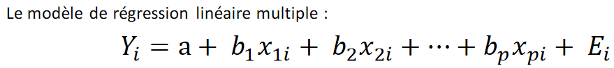

**Les étapes préalables:**

- Créer de **nouvelles variables** (calculer âge à partir de la date de naissance)
- **Analyse univariée**: analyser le contenu de chaque variable indépendamment des autres (pour s’approprier la variables, obtenir un ordre de grandeur, détecter d’éventuelles anomalies sur cette variable, obtenir une première répartition des variables)
- **Analyses bivariées**: analyser le contenu de 2 variables entre elles: il faut croiser les variables pertinentes et la variable à expliquer aux potentielles variables explicatives.
- **Discrétiser les variables**: découper une variable quantitative en classes de façon à simplifier la lecture et l’interprétation des données (regarder les quantiles ou construire des classes liées aux exigences métier).

**Quelles types de variables inclure dans le modèle?**

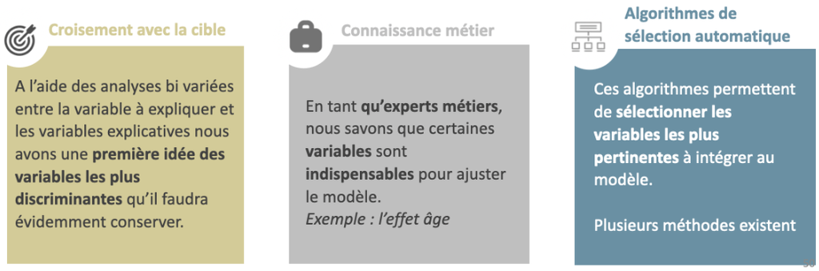

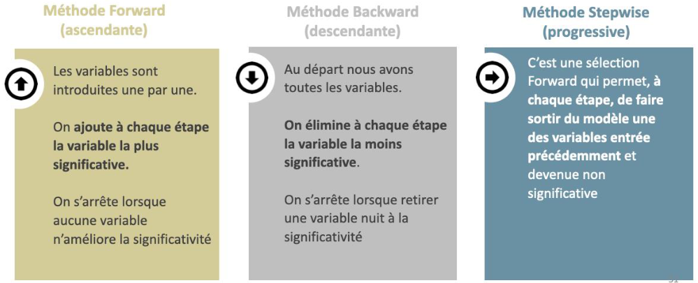

Sur la base Tips qui recense les pourboires (tips en anglais) de 244 clients donnés à un serveur dans un restaurant américain aux débuts des années 1990. Les données indiquent le prix du repas en dollars (TOTBILL), le pourboire (TIP), le sexe de la personne qui a payé et donné le pourboire (SEX=0 indique un homme, SEX=1 une femme) et si le repas était dans la zone fumeurs ou non (SMOKER=0 non-fumeur et SMOKER=1 fumeur), le jour où le repas a été pris (DAY=3 correspond à mardi, DAY=4 à mercredi etc), si c’était en journée ou en soirée (TIME=1 signifie en soirée) et enfin, le nombre de convives (SIZE). IDEN sert bien sûr à identifier un repas.

- Préparer les données et analyse univariée.
- Analyses bi variées : quelles variables sont liées au montant du pourboire ?
- Construire un modèle de régression linéaire multiple
- Prédire le pourboire que donnera un jeudi soir, un homme ayant dépensé 25 dollars et ayant mangé avec 5 convives dans la zone fumeurs.

# 1. Visualisation des données

```r
dataTip <- as_tibble(dataTip)

library(rmarkdown)
paged_table(dataTip)
```

| IDEN | TOTBILL | TIP | SEX | SMOKER | DAY | TIME | SIZE |
| --- | --- | --- | --- | --- | --- | --- | --- |
| R001 | 16.99 | 1.01 | 1 | 0 | 6 | 1 | 2 |
| R002 | 10.34 | 1.66 | 0 | 0 | 6 | 1 | 3 |
| R003 | 21.01 | 3.50 | 0 | 0 | 6 | 1 | 3 |
| R004 | 23.68 | 3.31 | 0 | 0 | 6 | 1 | 2 |
| R005 | 24.59 | 3.61 | 1 | 0 | 6 | 1 | 4 |
| R006 | 25.29 | 4.71 | 0 | 0 | 6 | 1 | 4 |
| R007 | 8.77 | 2.00 | 0 | 0 | 6 | 1 | 2 |
| R008 | 26.88 | 3.12 | 0 | 0 | 6 | 1 | 4 |
| R009 | 15.04 | 1.96 | 0 | 0 | 6 | 1 | 2 |
| R010 | 14.78 | 3.23 | 0 | 0 | 6 | 1 | 2 |

[output cut: 234 more lines]

# 2. Préparation des données

## Vérification des NA

Il n’y a pas de NA dans le jeu de données.

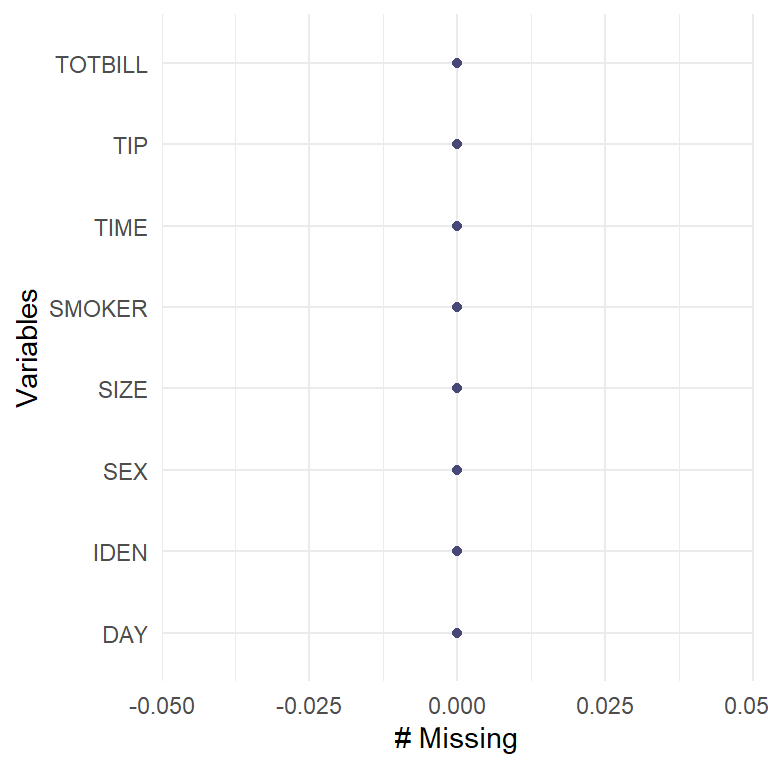

```r
library(naniar)
gg_miss_var(dataTip)
```

## Modification de la structure

```r
str(dataTip)
```

```
## tibble[,8] [244 x 8] (S3: tbl_df/tbl/data.frame)
##  $ IDEN   : chr [1:244] "R001 " "R002 " "R003 " "R004 " ...
##  $ TOTBILL: chr [1:244] " 16.99   " " 10.34   " " 21.01   " " 23.68   " ...
##  $ TIP    : num [1:244] 1.01 1.66 3.5 3.31 3.61 4.71 2 3.12 1.96 3.23 ...
##  $ SEX    : int [1:244] 1 0 0 0 1 0 0 0 0 0 ...
##  $ SMOKER : int [1:244] 0 0 0 0 0 0 0 0 0 0 ...
##  $ DAY    : int [1:244] 6 6 6 6 6 6 6 6 6 6 ...
##  $ TIME   : int [1:244] 1 1 1 1 1 1 1 1 1 1 ...
##  $ SIZE   : int [1:244] 2 3 3 2 4 4 2 4 2 2 ...
```

```r
as.numeric(dataTip$TOTBILL) # warning NA
```

```
##   [1] 16.99 10.34 21.01 23.68 24.59 25.29  8.77 26.88 15.04 14.78 10.27 35.26
##  [13] 15.42 18.43 14.83 21.58 10.33 16.29 16.97 20.65 17.92 20.29 15.77 39.42
##  [25] 19.82 17.81 13.37 12.69 21.70 19.65  9.55 18.35 15.06 20.69 17.78 24.06
##  [37] 16.31 16.93 18.69 31.27 16.04 17.46 13.94  9.68 30.40 18.29 22.23 32.40
##  [49] 28.55 18.04 12.54 10.29 34.81  9.94 25.56 19.49 38.01 26.41 11.24 48.27
##  [61] 20.29 13.81 11.02 18.29 17.59 20.08 16.45  3.07 20.23 15.01 12.02 17.07
##  [73] 26.86 25.28 14.73 10.51 17.92 27.20 22.76 17.29 19.44 16.66 10.07 32.68
##  [85] 15.98 34.83 13.03 18.28 24.71 21.16 28.97 22.49  5.75 16.32 22.75 40.17
##  [97] 27.28 12.03 21.01 12.46 11.35 15.38 44.30 22.42 20.92 15.36 20.49 25.21
## [109] 18.24 14.31 14.00  7.25 38.07 23.95 25.71 17.31 29.93 10.65 12.43 24.08
## [121] 11.69 13.42 14.26 15.95 12.48 29.80  8.52 14.52 11.38 22.82 19.08 20.27
## [133] 11.17 12.26 18.26  8.51 10.33 14.15 16.00 13.16 17.47 34.30 41.19 27.05
## [145] 16.43  8.35 18.64 11.87  9.78  7.51 14.07 13.13 17.26 24.55 19.77 29.85
## [157] 48.17 25.00 13.39 16.49 21.50 12.66 16.21 13.81 17.51 24.52 20.76 31.71
## [169] 10.59 10.63    NA 15.81  7.25 31.85 16.82 32.90 17.89 14.48  9.60 34.63
## [181] 34.65 23.33 45.35 23.17 40.55 20.69 20.90 30.46 18.15 23.10 15.69 19.81
## [193] 28.44 15.48 16.58  7.56 10.34 43.11 13.00 13.51 18.71 12.74 13.00 16.40
## [205] 20.53 16.47 26.59 38.73 24.27 12.76 30.06 25.89 48.33 13.27 28.17 12.90
## [217] 28.15 11.59  7.74 30.14 12.16 13.42  8.58 15.98 13.42 16.27 10.09 20.45
## [229] 13.28 22.12 24.01 15.69 11.61 10.77 15.53 10.07 12.60 32.83 35.83 29.03
## [241] 27.18 22.67 17.82 18.78
```

```r
dataTip$TOTBILL[is.na(as.numeric(dataTip$TOTBILL))] # on regarde la valeur qui ne peut être transformée en numérique " 50.81  1"
```

```
## [1] " 50.81  1"
```

```r
dataTip$TOTBILL <- as.numeric(dataTip$TOTBILL) # on convertit quand même en NA

dataTip$SEX <- as.factor(as.character(dataTip$SEX))
levels(dataTip$SEX) <- c("HOMME","FEMME") # car 0 en 1er lorsque l'on fait levels donc HOMME

dataTip$SMOKER <- as.factor(as.character(dataTip$SMOKER))
levels(dataTip$SMOKER) <- c("NONFUMEUR","FUMEUR")

dataTip$DAY <- as.factor(as.character(dataTip$DAY))
levels(dataTip$DAY) <- c("MARDI","MERCREDI","JEUDI","VENDREDI")

dataTip$TIME <- as.factor(as.character(dataTip$TIME))
levels(dataTip$TIME) <- c("MIDI","SOIR")

dataTip$SIZE = as.factor(as.character(dataTip$SIZE)) # on préfèrera stocker en character pour éviter tout calcul dessus, on ne peut pas manger à 2,5 à une table
```

# 3. Analyses univariées

```r
library(skimr)
skim(dataTip)
```

Data summary

| Name | dataTip |
| --- | --- |
| Number of rows | 244 |
| Number of columns | 8 |
| _______________________ |  |
| Column type frequency: |  |
| character | 1 |
| factor | 5 |
| numeric | 2 |
| ________________________ |  |
| Group variables | None |

**Variable type: character**

| skim_variable | n_missing | complete_rate | min | max | empty | n_unique | whitespace |
| --- | --- | --- | --- | --- | --- | --- | --- |
| IDEN | 0 | 1 | 5 | 5 | 0 | 244 | 0 |

**Variable type: factor**

| skim_variable | n_missing | complete_rate | ordered | n_unique | top_counts |
| --- | --- | --- | --- | --- | --- |
| SEX | 0 | 1 | FALSE | 2 | HOM: 157, FEM: 87 |
| SMOKER | 0 | 1 | FALSE | 2 | NON: 151, FUM: 93 |
| DAY | 0 | 1 | FALSE | 4 | JEU: 87, VEN: 76, MAR: 62, MER: 19 |
| TIME | 0 | 1 | FALSE | 2 | SOI: 176, MID: 68 |
| SIZE | 0 | 1 | FALSE | 6 | 2: 156, 3: 38, 4: 37, 5: 5 |

**Variable type: numeric**

| skim_variable | n_missing | complete_rate | mean | sd | p0 | p25 | p50 | p75 | p100 | hist |
| --- | --- | --- | --- | --- | --- | --- | --- | --- | --- | --- |
| TOTBILL | 1 | 1 | 19.66 | 8.69 | 3.07 | 13.32 | 17.78 | 24.07 | 48.33 | ▃▇▃▁▁ |
| TIP | 0 | 1 | 2.96 | 1.32 | 0.00 | 2.00 | 2.86 | 3.52 | 9.00 | ▂▇▂▁▁ |

Avec funModeling: + rapide mais moins détaillé

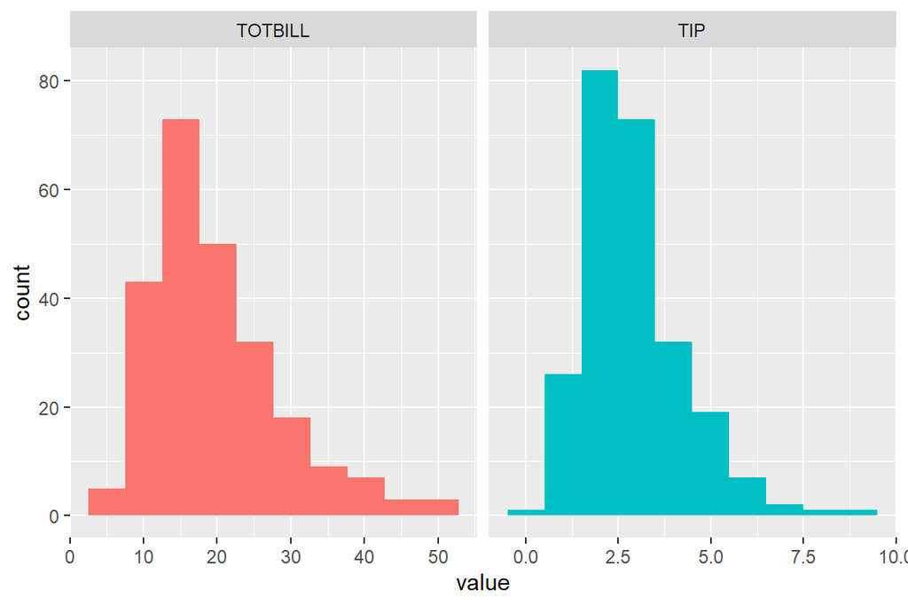

```r
library(funModeling)
plot_num(dataTip)
```

Avec un histogramme: - rapide mais plus détaillé

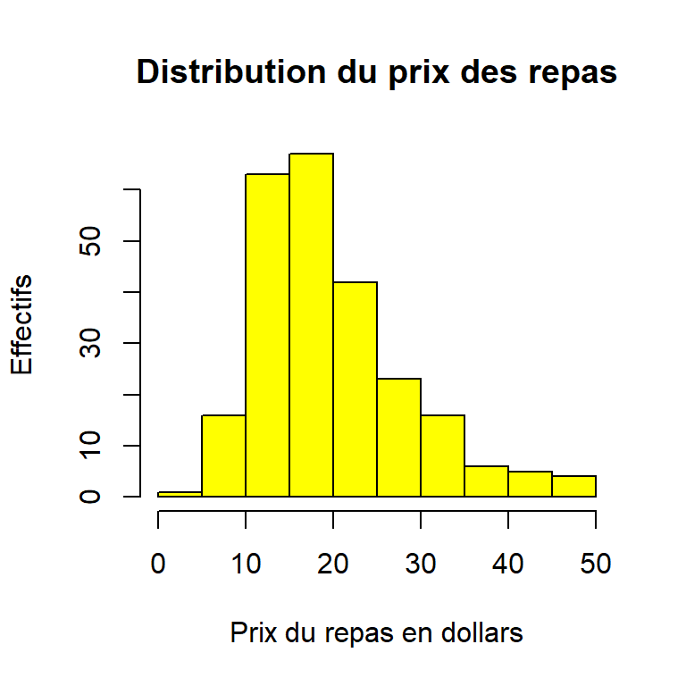

```r
hist(dataTip$TOTBILL,main="Distribution du prix des repas",ylab="Effectifs", xlab="Prix du repas en dollars", col="yellow")
```

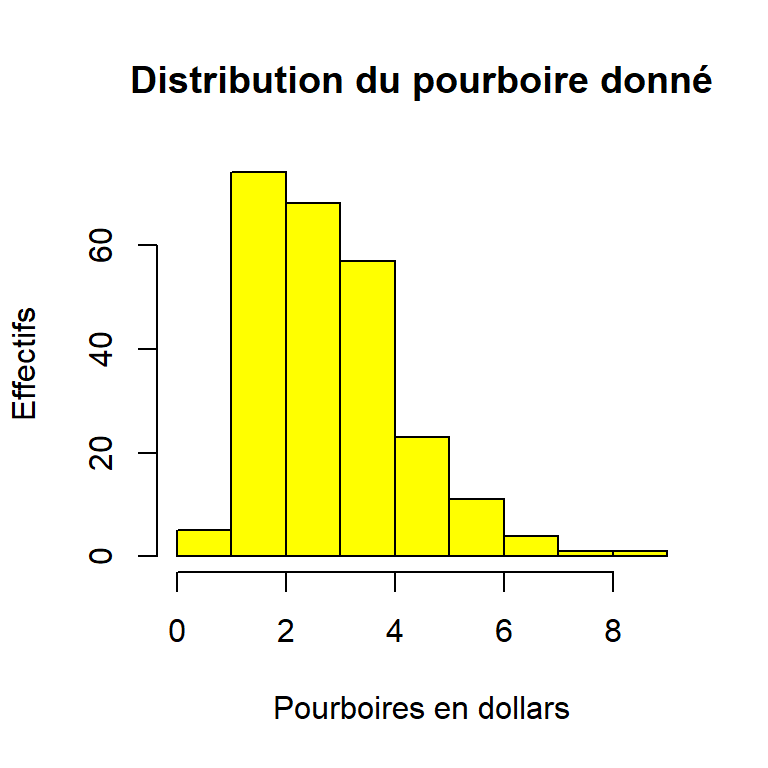

```r
hist(dataTip$TIP, main="Distribution du pourboire donné", ylab="Effectifs", xlab="Pourboires en dollars", col="yellow")
```

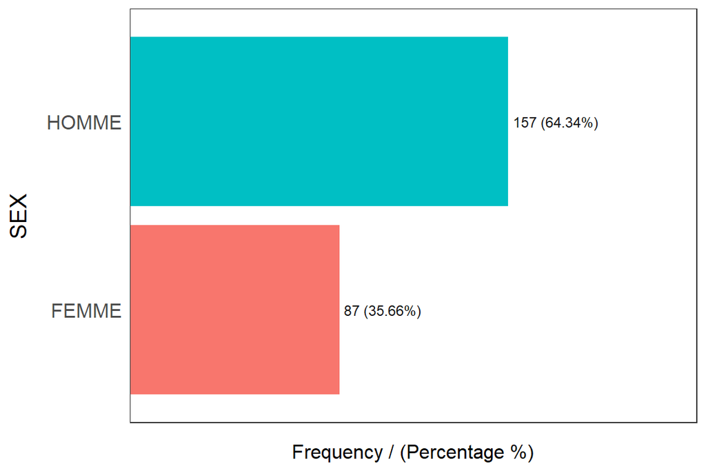

```
##     SEX frequency percentage cumulative_perc
## 1 HOMME       157      64.34           64.34
## 2 FEMME        87      35.66          100.00
```

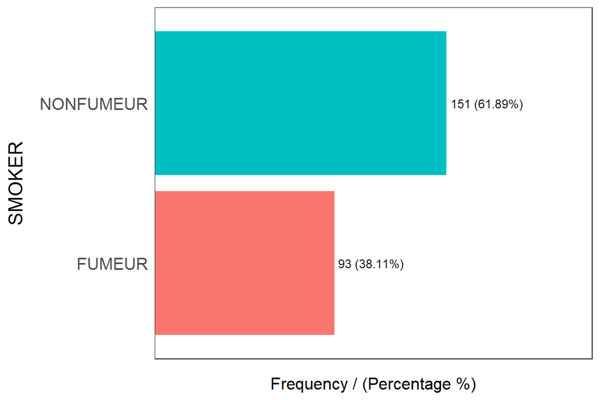

```
##      SMOKER frequency percentage cumulative_perc
## 1 NONFUMEUR       151      61.89           61.89
## 2    FUMEUR        93      38.11          100.00
```

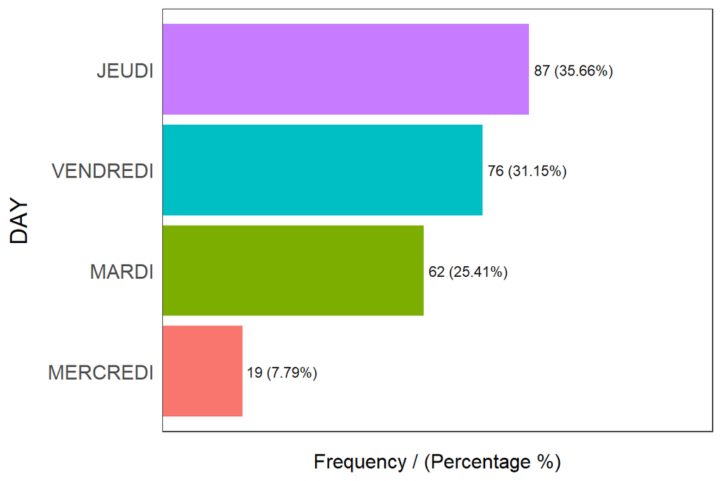

```
##        DAY frequency percentage cumulative_perc
## 1    JEUDI        87      35.66           35.66
## 2 VENDREDI        76      31.15           66.81
## 3    MARDI        62      25.41           92.22
## 4 MERCREDI        19       7.79          100.00
```

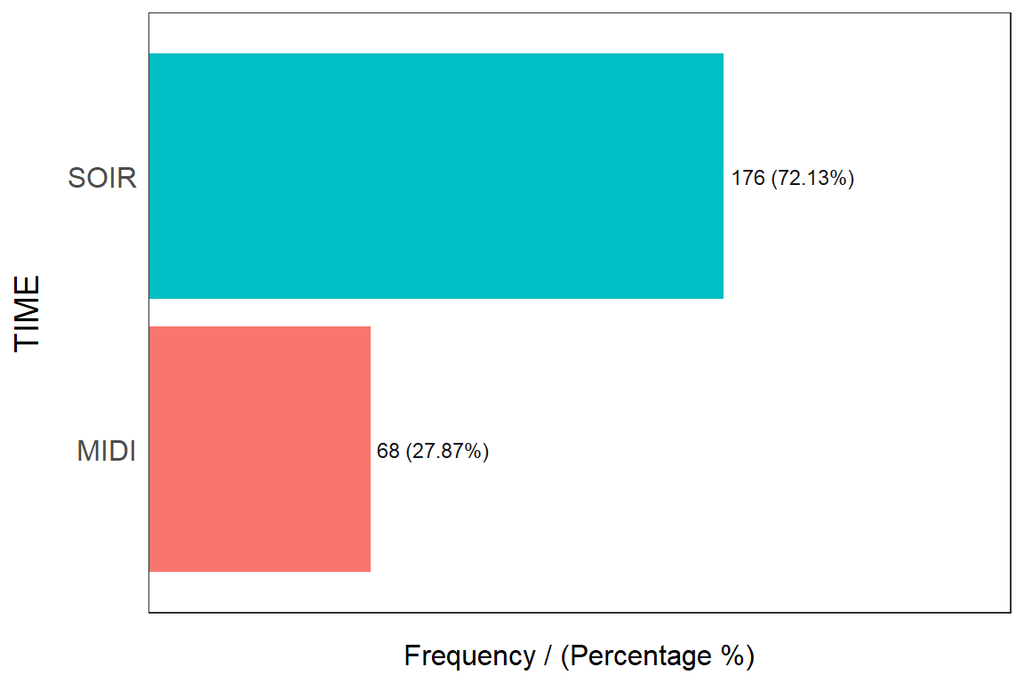

```
##   TIME frequency percentage cumulative_perc
## 1 SOIR       176      72.13           72.13
## 2 MIDI        68      27.87          100.00
```

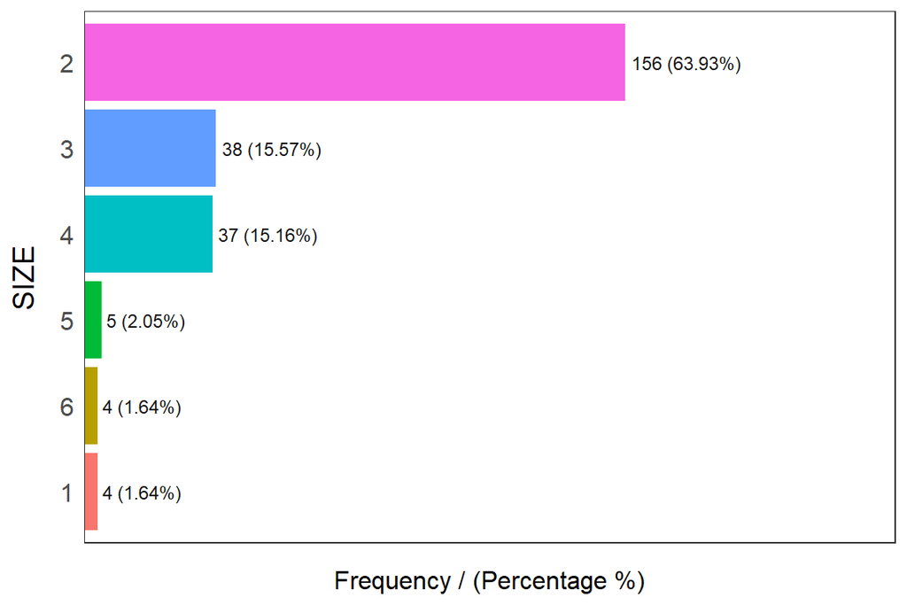

```
##   SIZE frequency percentage cumulative_perc
## 1    2       156      63.93           63.93
## 2    3        38      15.57           79.50
## 3    4        37      15.16           94.66
## 4    5         5       2.05           96.71
## 5    1         4       1.64           98.35
## 6    6         4       1.64          100.00
```

```
## [1] "Variables processed: SEX, SMOKER, DAY, TIME, SIZE"
```

```r
freq(dataTip, c("SEX", "SMOKER", "DAY", "TIME", "SIZE"))
```

Cette dernière représentation graphique montre que certaines modalités sont très faiblement représentées (repas à 1, ou 5 et 6). Pour éviter que cela ne biaise les analyses suivantes, nous proposons de découper la variable en classe. Nous proposons de construire deux classes en regroupant les modalités 1 et 2 Vs 3 et + afin d’avoir deux classes assez grandes.

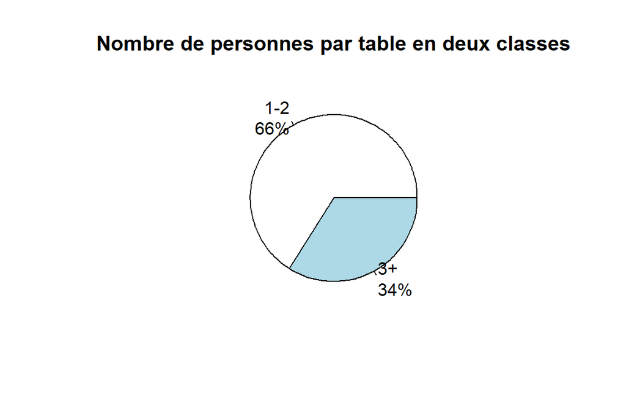

```r
dataTip$SIZE2cl <- ifelse(as.numeric(as.character(dataTip$SIZE)) > 2,"3+","1-2")

tab_barSIZE2cl_cont <- round(prop.table(table(dataTip$SIZE2cl))*100,0)
lbls = paste(names(tab_barSIZE2cl_cont), "\n", tab_barSIZE2cl_cont, "%", sep="")
pie(tab_barSIZE2cl_cont, labels = lbls,main = "Nombre de personnes par table en deux classes")
```

Dans cet échantillon, le prix d’un repas est en moyenne 20 Dollars (SD : 9). Le pourboire est en moyenne 3 dollars (SD : 1). La majorité des clients sont des hommes (64%), elle fréquente la salle non fumeur (62%) et le plus souvent par table de deux (64%). Le jeudi est le jour le plus fréquenté (36%) et le soir est plus représenté (72%).

# 4. Analyses bivariées

## TIP vs TOTBILL (2 variables quantitatives => nuage de points)

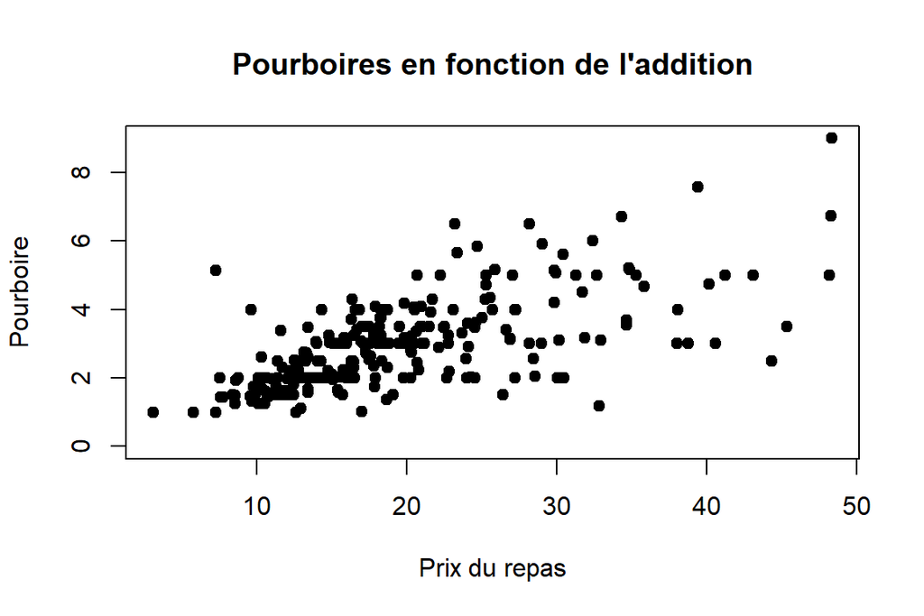

```r
plot(TIP ~ TOTBILL, data=dataTip, ylab = "Pourboire", xlab = "Prix du repas", main = "Pourboires en fonction de l'addition", pch=19)
```

```r
# La relation semble linéaire, le coefficient de pearson est :
cat(cor(dataTip$TOTBILL,dataTip$TIP, method="pearson", use = "pairwise.complete.obs"))
```

```
## 0.654162
```

On observe une corrélation positive, relativement élevée, indiquant que les montants des pourboires semblent être plus élevés pour des repas plus coûteux.

## TIP vs SEX (variable quantitative en fonction d’une qualitative => boxplot)

Les statistiques des pourboires selon le sexe du client sont données ci dessous :

```r
paged_table(dataTip %>% group_by(SEX) %>% summarise(Moyenne = mean(TIP), Ecart.type = sd(TIP), Mediane= median(TIP), Q1 = quantile(TIP, 0.25), Q3 = quantile(TIP, 0.75), Min= min(TIP), Max = max(TIP)))
```

| SEX | Moyenne | Ecart.type | Mediane | Q1 | Q3 | Min | Max |
| --- | --- | --- | --- | --- | --- | --- | --- |
| HOMME | 3.025924 | 1.403004 | 3.00 | 2 | 3.71 | 0 | 9.0 |
| FEMME | 2.833448 | 1.159495 | 2.75 | 2 | 3.50 | 1 | 6.5 |

Les pourboires semblent être légèrement plus élevés chez les hommes (moyenne et médiane). Les boites à moustache mettent en évidence une dispersion des pourboires plus importante chez les hommes, par rapport aux femmes.

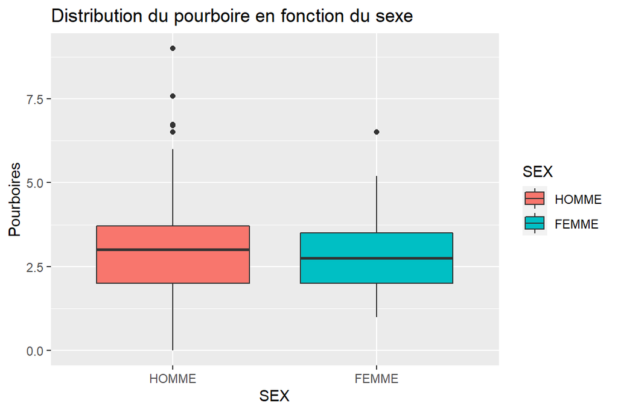

```r
qplot(SEX, TIP, data = dataTip, ylab= "Pourboires",
      main = "Distribution du pourboire en fonction du sexe", geom = "boxplot", fill = SEX)
```

## TIP vs SMOKER (variable quantitative en fonction d’une qualitative => boxplot)

Les montants des pourboires sont supérieurs en médiane chez les fumeurs (médiane=3.00) versus les non-fumeurs (médiane=2.74).

```r
paged_table(dataTip %>%
  group_by(SMOKER) %>%
  summarise(Moyenne = mean(TIP), Ecart.type = sd(TIP), Mediane= median(TIP), Q1 = quantile(TIP, 0.25), Q3 = quantile(TIP, 0.75), Min= min(TIP), Max = max(TIP)))
```

| SMOKER | Moyenne | Ecart.type | Mediane | Q1 | Q3 | Min | Max |
| --- | --- | --- | --- | --- | --- | --- | --- |
| NONFUMEUR | 2.991854 | 1.377190 | 2.74 | 2 | 3.505 | 1 | 9.0 |
| FUMEUR | 2.901183 | 1.232694 | 3.00 | 2 | 3.550 | 0 | 6.5 |

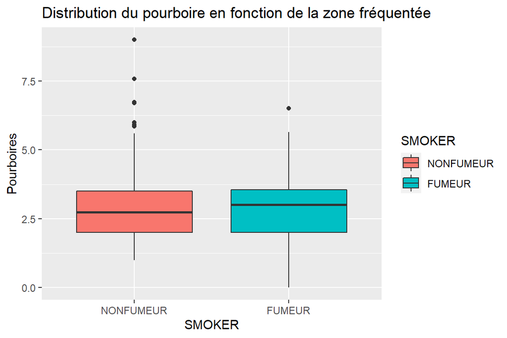

```r
qplot(SMOKER, TIP, data = dataTip, ylab= "Pourboires",
      main = "Distribution du pourboire en fonction de la zone fréquentée", geom = "boxplot", fill = SMOKER)
```

## TIP vs DAY (variable quantitative en fonction d’une qualitative => boxplot)

On remarque que les montants des pourboires sont légérement plus élevés le vendredi (en moyenne et médiane). Cette tendance est visible graphiquement par les boites à moustache.

```r
paged_table(dataTip %>%
  group_by(DAY) %>%
  summarise(Moyenne = mean(TIP), Ecart.type = sd(TIP), Mediane= median(TIP), Q1 = quantile(TIP, 0.25), Q3 = quantile(TIP, 0.75), Min= min(TIP), Max = max(TIP)))
```

| DAY | Moyenne | Ecart.type | Mediane | Q1 | Q3 | Min | Max |
| --- | --- | --- | --- | --- | --- | --- | --- |
| MARDI | 2.771452 | 1.240223 | 2.305 | 2.0000 | 3.3625 | 1.25 | 6.70 |
| MERCREDI | 2.734737 | 1.019577 | 3.000 | 1.9600 | 3.3650 | 1.00 | 4.73 |
| JEUDI | 2.878161 | 1.476524 | 2.720 | 2.0000 | 3.3100 | 0.00 | 9.00 |
| VENDREDI | 3.255132 | 1.234880 | 3.150 | 2.0375 | 4.0000 | 1.01 | 6.50 |

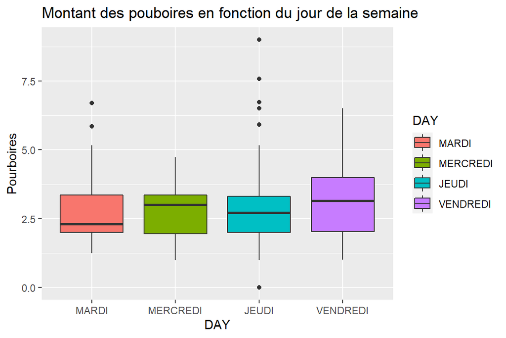

```r
qplot(DAY, TIP, data = dataTip, ylab= "Pourboires",
      main = "Montant des pouboires en fonction du jour de la semaine", geom = "boxplot", fill = DAY)
```

## TIP vs TIME (variable quantitative en fonction d’une qualitative => boxplot)

Si on regarde maintenant la distribution des pourboires selon le moment de la journée (midi ou soir), on peut voir que la médiane des montants des pourboires est plus élevée pour les repas du soir versus le midi.

```r
paged_table(dataTip %>%
  group_by(TIME) %>%
  summarise(Moyenne = mean(TIP), Ecart.type = sd(TIP), Mediane= median(TIP), Q1 = quantile(TIP, 0.25), Q3 = quantile(TIP, 0.75), Min= min(TIP), Max = max(TIP)))
```

| TIME | Moyenne | Ecart.type | Mediane | Q1 | Q3 | Min | Max |
| --- | --- | --- | --- | --- | --- | --- | --- |
| MIDI | 2.728088 | 1.205345 | 2.25 | 2 | 3.2875 | 1.25 | 6.7 |
| SOIR | 3.045852 | 1.357464 | 3.00 | 2 | 3.6275 | 0.00 | 9.0 |

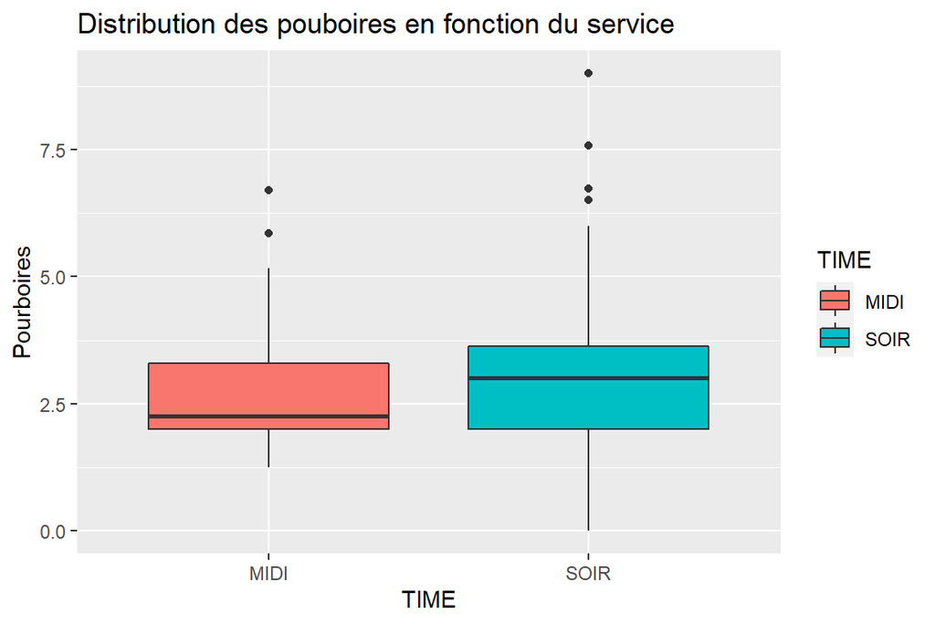

```r
qplot(TIME, TIP, data = dataTip, ylab= "Pourboires",
      main = "Distribution des pouboires en fonction du service", geom = "boxplot", fill = TIME)
```

## TIP vs SIZECATEG (variable quantitative en fonction d’une qualitative => boxplot)

Enfin, l’étude des montants des pourboires selon le nombre de convives à table montre que la médiane du prix par repas est plus élevée sur les plus grandes tables.

```r
paged_table(dataTip %>%
  group_by(SIZE2cl) %>%
  summarise(Moyenne = mean(TIP), Ecart.type = sd(TIP), Mediane= median(TIP), Q1 = quantile(TIP, 0.25), Q3 = quantile(TIP, 0.75), Min= min(TIP), Max = max(TIP)))
```

| SIZE2cl | Moyenne | Ecart.type | Mediane | Q1 | Q3 | Min | Max |
| --- | --- | --- | --- | --- | --- | --- | --- |
| 1-2 | 2.553688 | 0.9918502 | 2.39 | 1.9675 | 3.1175 | 1 | 5.85 |
| 3+ | 3.726071 | 1.5234710 | 3.50 | 2.7150 | 4.7975 | 0 | 9.00 |

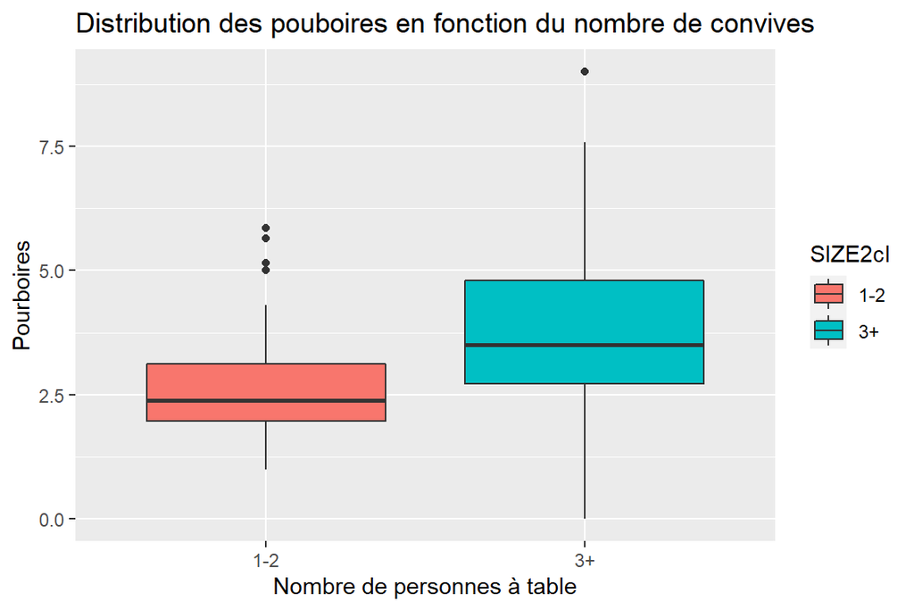

```r
qplot(SIZE2cl, TIP, data = dataTip, ylab= "Pourboires", xlab = "Nombre de personnes à table",
      main = "Distribution des pouboires en fonction du nombre de convives", geom = "boxplot", fill = SIZE2cl)
```

# 5. Régression linéaire univariée

## Mettre en place les régressions linéaires à un seul facteur pour étudier l’association entre chaque variable prédictive et la variable à expliquer

Dans un premier temps, nous allons faire des modèles avec une seule variable explicative, afin d’étudier l’association entre cette variable et notre variable Pourboire. Notre objectif est ici descriptif.

Le code R ci-dessous permet grâce à l’instruction lm d’estimer les coefficients des modèles donnés par

Pourboire = β0 + β1 × nomvar + ϵ

pour chaque variable explicative nomvar issue de la base de données dataTip.

Les estimations des coefficients du modèle sont données par l’instruction coeff.

Pour chaque coefficient, les tables ci-dessous donnent également la probabilité critique associée au test d’hypothèse:

H0:β1 = 0 et β1≠0

afin de tester la nullité de la pente, et donc l’absence de relation entre notre variable à expliquer Pourboire et la variable explicative.

```r
variable <- c("TOTBILL", "SEX", "SMOKER", "DAY", "TIME", "SIZE2cl")

for (i in variable){
  cat("Coefficients du modèle linéaire TIP (variable à expliquer) en fonction de ",i," (variable explicative)")
  coeff=summary(lm(TIP ~ unlist(dataTip[,i]), dataTip))$coefficients
  rownames(coeff)=gsub("dataTip\\[, i\\]",i,rownames(coeff))
  print(kable(coeff))
  cat('\n')}
```

```
## Coefficients du modèle linéaire TIP (variable à expliquer) en fonction de  TOTBILL  (variable explicative)
##
## |                |  Estimate| Std. Error|   t value| Pr(>&#124;t&#124;)|
## |:---------------|---------:|----------:|---------:|------------------:|
## |(Intercept)     | 1.0301891|  0.1578762|  6.525296|                  0|
## |unlist(TOTBILL) | 0.0986494|  0.0073473| 13.426674|                  0|
##
## Coefficients du modèle linéaire TIP (variable à expliquer) en fonction de  SEX  (variable explicative)
##
## |                 |   Estimate| Std. Error|   t value| Pr(>&#124;t&#124;)|
## |:----------------|----------:|----------:|---------:|------------------:|
## |(Intercept)      |  3.0259236|  0.1054765| 28.688130|          0.0000000|
## |unlist(SEX)FEMME | -0.1924753|  0.1766408| -1.089642|          0.2769546|
##
## Coefficients du modèle linéaire TIP (variable à expliquer) en fonction de  SMOKER  (variable explicative)
##
## |                     |   Estimate| Std. Error|    t value| Pr(>&#124;t&#124;)|
## |:--------------------|----------:|----------:|----------:|------------------:|
## |(Intercept)          |  2.9918543|  0.1077551| 27.7653156|          0.0000000|
## |unlist(SMOKER)FUMEUR | -0.0906715|  0.1745385| -0.5194929|          0.6038919|
##
## Coefficients du modèle linéaire TIP (variable à expliquer) en fonction de  DAY  (variable explicative)
##
## |                    |   Estimate| Std. Error|    t value| Pr(>&#124;t&#124;)|
## |:-------------------|----------:|----------:|----------:|------------------:|
## |(Intercept)         |  2.7714516|  0.1668814| 16.6073098|          0.0000000|
## |unlist(DAY)MERCREDI | -0.0367148|  0.3445670| -0.1065533|          0.9152323|
## |unlist(DAY)JEUDI    |  0.1067093|  0.2183944|  0.4886082|          0.6255652|
## |unlist(DAY)VENDREDI |  0.4836800|  0.2248748|  2.1508857|          0.0324841|
##
## Coefficients du modèle linéaire TIP (variable à expliquer) en fonction de  TIME  (variable explicative)
##
## |                 | Estimate| Std. Error|   t value| Pr(>&#124;t&#124;)|
## |:----------------|--------:|----------:|---------:|------------------:|
## |(Intercept)      | 2.728088|  0.1597229| 17.080135|           0.000000|
## |unlist(TIME)SOIR | 0.317764|  0.1880640|  1.689659|           0.092381|
##
## Coefficients du modèle linéaire TIP (variable à expliquer) en fonction de  SIZE2cl  (variable explicative)
##
## |                  | Estimate| Std. Error|   t value| Pr(>&#124;t&#124;)|
## |:-----------------|--------:|----------:|---------:|------------------:|
## |(Intercept)       | 2.553688|  0.0949471| 26.895898|                  0|
## |unlist(SIZE2cl)3+ | 1.172384|  0.1618218|  7.244908|                  0|
```

Remarque : Lorsqu’il s’agit d’une variable qualitative à plusieurs modalités (exemple de la variable DAY), plusieurs choix s’offrent à nous selon ce qu’on souhaite étudier. On peut soit évaluer l’effet d’un jour contre tous (dans ce cas il faut créer plusieurs variables binaires) ou soit choisir un jour de référence (ici, pour notre exemple : Mardi) et étudier l’effet des autres modalités comparé à la référence. C’est la raison pour laquelle le tableau indique DayMercredi, DayJeudi et DayVendredi. Ici, R a choisi comme modalité par défaut la “première”.

Il est possible de changer la modalité de référence avec la fonction relevel et l’instruction ref.

## Construction du modèle final (pvalue < 0.2)

**Pour construire le modèle final, nous allons sélectionner les variables prédictives qui présentent une pvalue < 0.2.**

```r
variable_select <- c("TOTBILL","DAY", "TIME", "SIZE2cl")
```

# 6. Modèle multivarié

## Régression linéaire multivariée

```r
full.model <- lm(TIP ~., data = na.omit(dataTip[ ,c("TIP",variable_select)]))
```

## Méthode de sélection de variables : la méthode stepwise

La méthode stepwise de sélection de variables est une combinaison des méthodes ascendante et descendante. Après chaque introduction de variable, la procédure stepwise réexamine l’ensemble des variables du modèle et regarde si l’ajout d’une variable ne provoque pas le retrait d’une autre, ie. elle élimine les variables les moins significatives (s’il y en a). Pour ce faire, le critère de l’AIC est utilisé : il est alors calculé pour tous les modèles concurrents, le but étant de minimiser ce critère. Lorsque le nombre d’observations est important, on préconisera plutôt d’utiliser le critère du BIC

```r
library(MASS)
step.model <- stepAIC(full.model, direction = "both", trace = FALSE)
summary(step.model)
```

```
##
## Call:
## lm(formula = TIP ~ TOTBILL + SIZE2cl, data = na.omit(dataTip[,
##     c("TIP", variable_select)]))
##
## Residuals:
##     Min      1Q  Median      3Q     Max
## -2.8737 -0.6183 -0.0715  0.5102  3.3944
##
## Coefficients:
##             Estimate Std. Error t value Pr(>|t|)
## (Intercept) 1.110419   0.161916   6.858 5.88e-11 ***
## TOTBILL     0.088992   0.008747  10.175  < 2e-16 ***
## SIZE2cl3+   0.320901   0.160020   2.005    0.046 *
## ---
## Signif. codes:  0 '***' 0.001 '**' 0.01 '*' 0.05 '.' 0.1 ' ' 1
##
## Residual standard error: 0.9875 on 240 degrees of freedom
## Multiple R-squared:  0.4374, Adjusted R-squared:  0.4327
## F-statistic: 93.28 on 2 and 240 DF,  p-value: < 2.2e-16
```

Le modèle final est donc:

Pourboire = 1.11 + 0.09 × Totbill + 0.32×Size(1-2 ou + de 3)

Les pvaleurs pour chaque terme testent l’hypothèse nulle que le coefficient soit égal à zéro. On peut voir que le montant total du repas semble etre lié de façon très significative avec le montant du pourboire. La relation entre le nombre de convives à table et le montant du pourboire est également significative, toutefois dans une moindre mesure (p = 0,046).

## Vérification des conditions du modèle

Il faut ensuite examiner les graphiques des valeurs résiduelles, afin de déterminer si le modèle est adapté. Plus précisément, il faut vérifier : - l’indépendance des résidus, - la distribution gaussienne des résidus, - l’adéquation, - l’homoscedasticité des résidus (i.e. les résidus ont la même variance quelque soit le groupe considéré, ou quelle que soit la valeur de la variable explicative considérée).

### Représentation des résidus

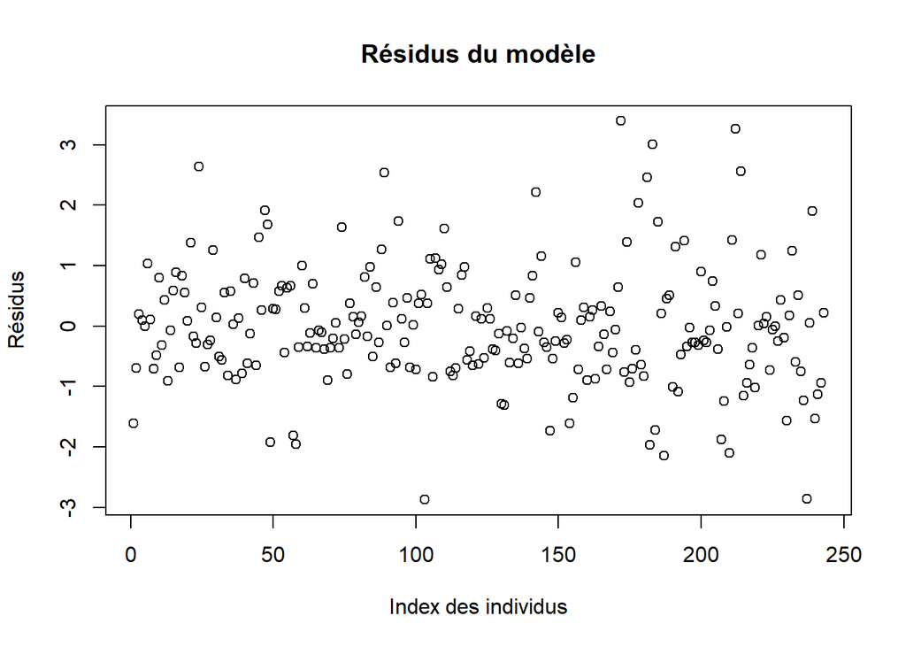

```r
plot(summary(step.model)$residuals,ylab="Résidus",xlab="Index des individus",main="Résidus du modèle")
```

### Validation des hypothèses

**Le premier graphe ”Residual vs Fitted”** trace les résidus en fonction des valeurs prédites. Les points doivent être répartis aléatoirement autour de l’axe horizontal y = 0 et le nuage de points ne doit pas avoir de structure particulière.

**Le graphe ”Scale-Location”** donne la racine des résidus standardisés en fonction des valeurs prédites et ne doit pas non plus avoir de structure particulière ni montrer de tendance.

**Le graphe ”Normal Q-Q”** permet de vérifier la normalité des résidus en comparant les quantiles de la population avec ceux de la loi normale. Ce graphique peut être réalisé à partir de la fonction qqnorm.

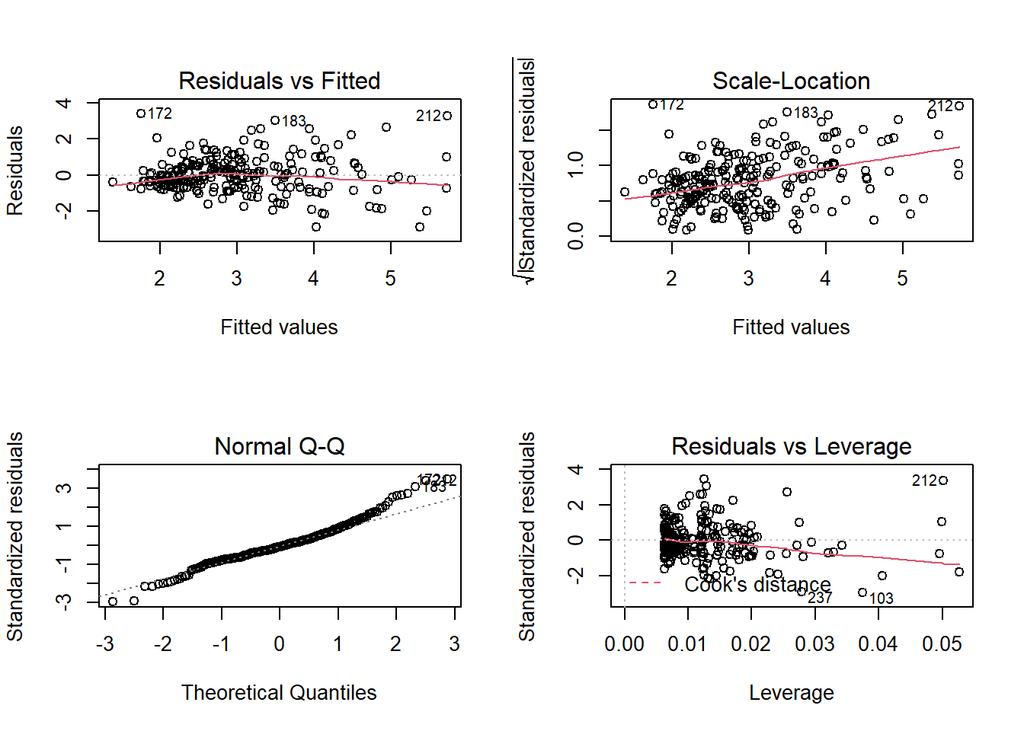

```r
layout(matrix(1:4,2,2)) # fenetre graphique coupée en 4
plot(step.model)
```

On peut aussi afficher les résidus studentisés qui en pratique devront être compris entre les bornes −2 et 2.

Graphiquement, on peut vérifier que la plupart des résidus studentisés se trouvent dans l’intervalle [-2,2]. On peut également constater que le graphique des résidus ne présente pas de structure, et que le nuage de points est réparti de part et d’autre de l’axe des x.

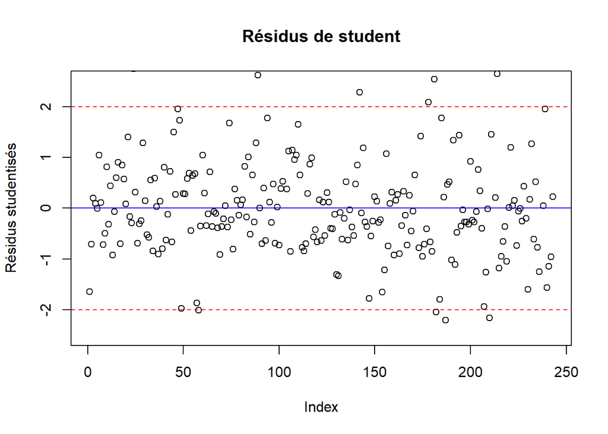

```r
# residus studentisés
res <- rstudent(step.model)

# tracé des résidus studentisés (ylim échelle pour y)
plot(res,ylab="Résidus studentisés",xlab="Index",main="Résidus de student",ylim=c(-2.5,2.5))

# tracés des droites y=0 (trait plein bleu), y=+/- 2 (trait espacé rouge)

# h= contient équation y=(-2,0,2) et lty le type de lignes
abline(h=c(-2,0,2),lty=c(2,1,2),col=c("red","blue","red"))
```

# 7. Validation du modèle

La qualité du modèle s’apprécie en regardant le graphique des erreurs résiduelles, comme fait précédemment.

On peut également tracer le graphique des valeurs prédites vs. les valeurs observées. Ce tracé est particulièrement utile pour identifier les groupes potentiels d’observations qui ne sont pas bien prédits.

Afin d’obtenir les valeurs prédites, on utilise la commande fitted.

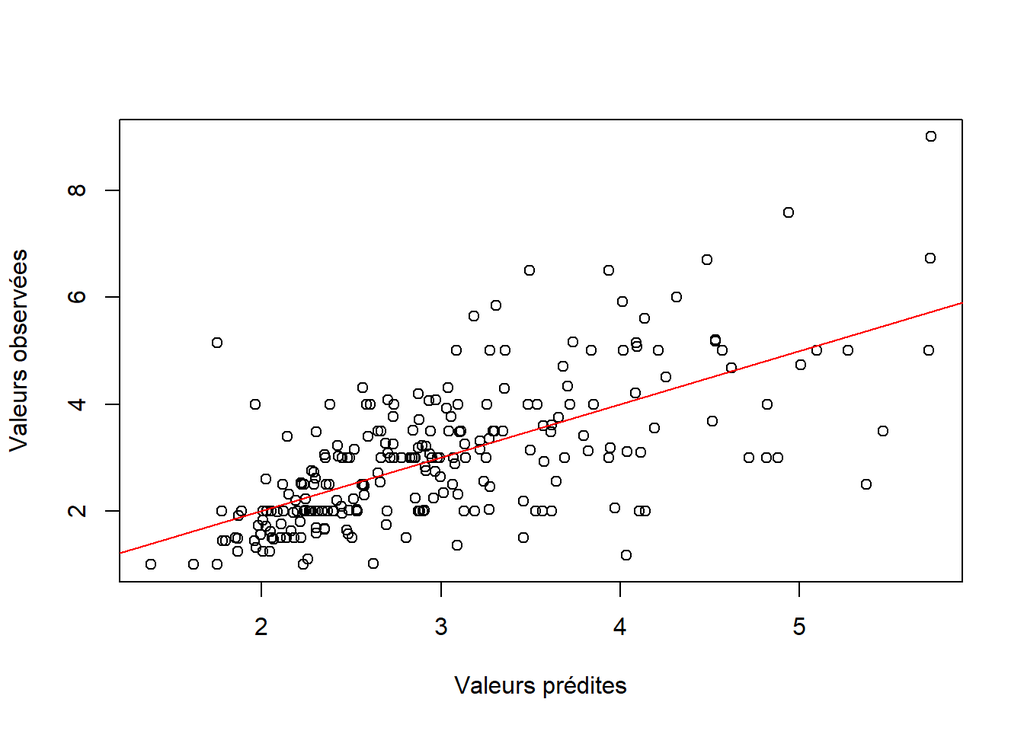

```r
pred <- fitted(step.model)
plot(pred, dataTip$TIP[-171], xlab="Valeurs prédites", ylab="Valeurs observées") # - 171 pour non prise en compte du NA
 abline(a=0,b=1,col="red")
```

On remarque que le nuage de points se répartit globalement autour de la droite d’équation y=x.

- La partie `Residuals` des résultats permet d’évaluer rapidement la normalité des résidus. Lorsque les résidus sont distribués selon une loi Normale, la médiane doit être autour de 0 (OK), et les valeurs absolues de Q1 et Q3 doivent être proches (OK).
- Ordonnée à l’origine (a) = 1.110419
- Coef de la pente TOTBILL (b) = 0.088992 (Une augmentation de 1€ de l’addition correspond à une augmentation des pourboires de 0.09€)
- Coef de la pente SIZE2cl3+ (b) = 0.320901 (Le fait d’être 3 ou + à table correspond à une augmentation des pourboires de 0.32€)

La significativité de la pente dépend de la dispersion des points autour de la droite de régression. C’est donc le niveau de la p-value qui va permettre de trancher. Une p-value inférieure à 0.05 (c’est le cas ici), permet de conclure à un lien linéaire significatif entre la variable réponse et la variable prédictive.

Le sens de la relation est donné par le signe du coefficient : s’il est positif, la relation linéaire est croissante, s’il est négatif, alors la relation linéaire est décroissante.

- Le R2 (Multiple R_squared) correspond à un indicateur de qualité de la régression linéaire. Il mesure la force de la relation entre les X et Y. C’est la part de variabilité expliquée par le modèle linéaire par le paramètre Y. Ici, 44% de la variabilité totale du pourboire est expliqué par sa dépendance aux variables TOTBILL et SIZE2cl3+ / le modèle de régression linéaire est capable de prendre en compte 44% de la variabilité des pourboires (i.e. il reste 56% de la variabilité totale du pourboire qui n’est pas expliquée par le modèle)

```r
summary(step.model)
```

```
##
## Call:
## lm(formula = TIP ~ TOTBILL + SIZE2cl, data = na.omit(dataTip[,
##     c("TIP", variable_select)]))
##
## Residuals:
##     Min      1Q  Median      3Q     Max
## -2.8737 -0.6183 -0.0715  0.5102  3.3944
##
## Coefficients:
##             Estimate Std. Error t value Pr(>|t|)
## (Intercept) 1.110419   0.161916   6.858 5.88e-11 ***
## TOTBILL     0.088992   0.008747  10.175  < 2e-16 ***
## SIZE2cl3+   0.320901   0.160020   2.005    0.046 *
## ---
## Signif. codes:  0 '***' 0.001 '**' 0.01 '*' 0.05 '.' 0.1 ' ' 1
##
## Residual standard error: 0.9875 on 240 degrees of freedom
## Multiple R-squared:  0.4374, Adjusted R-squared:  0.4327
## F-statistic: 93.28 on 2 and 240 DF,  p-value: < 2.2e-16
```

# 8. Prédictions

Le pourboire estimé pour une addition de 25€, pour un fumeuse, le jeudi en soirée pour une table de + 3 personne serait de 3.65 euros

```r
predict(step.model, newdata = data.frame(TOTBILL = 25, SMOKER = "FUMEUR", DAY = "JEUDI", TIME = "SOIREE",
                                     SIZE2cl = "3+"), se.fit=TRUE, interval = "prediction", level = 0.95)
```

```
## $fit
##        fit      lwr      upr
## 1 3.656131 1.698985 5.613277
##
## $se.fit
## [1] 0.1089816
##
## $df
## [1] 240
##
## $residual.scale
## [1] 0.9875315
```